# データ解析論II第2講

## 目次

## 一般線形モデルの復習

## 概要

一般線形モデルとは，統計学の中でも，以下の数式（モデル式）を元に考えていくモデルです．

\[Y_i=\beta_1 X_1 +\beta_2 X_2+ \beta_3 X_3 + .... \alpha+\epsilon_i \]

さて，何か複雑そうなモデル式が出てきてしまいましたが，恐れることはありません．少し，簡単な形にしてあげましょう．そうすると，こんな感じに書くことが出来ます．

\[Y_i=\beta_1 X_1 + \alpha+\epsilon_i \]

このモデル式，何だか見覚えのあるグラフとそっくりだと思います．中学校の時に“一次関数”というのを教わったのを覚えていますでしょうか？一次関数ではこんな数式を使いました．

\[Y=\beta X + \alpha\]

この数式を元に，グラフを書く，ということもやったかと思います．この時，\(\beta\) を傾き，\(\alpha\) を切片という呼び方をしていました．ちなみに，この数式で直線のグラフを書く時には，Xに0を代入した時のポイント(0, \(\alpha\))とXに1を代入したときのポイント(1, \(\beta + \alpha\))を結ぶ直線を引いてあげれば，グラフを作成することができます．

一般線形モデルの一番理解しやすい最初の考え方は，「実際に観察されたデータを元にして，一次関数のような直線を引いてあげよう！」という発想です．ただし，一次関数とちょっと違うのは「全ての点を通らなくてよい」ということです．

## 確認問題

“SUB_SLP”は睡眠満足度に関するデータであった（各10点尺度）．これらを応答変数，地域を表す“ARE”を説明変数として，以下の分析を実施せよ．

- 睡眠満足度の地域差を分析せよ．

## 確認問題

“SUB_SLP”は睡眠満足度に関するデータであった（各10点尺度）．これらを応答変数，年代を表す“GEN”を説明変数として，以下の分析を実施せよ．

- 睡眠満足度の年代差を分析せよ．

## 確認問題

“SUB_SLP”は睡眠満足度に関するデータであった（各10点尺度）．これらを応答変数，性別を表す“F_SEX”及び結婚を示す“MAR”(0:未婚，1:既婚)を説明変数として，以下の「交互作用*あり*」の分析を実施せよ．それぞれについてグラフ，分散分析表とモデルの結果を出力すること．

- 睡眠満足度の性別差（男女その他）および既婚・未婚の影響を分析せよ．

## 確認問題

“SUB_SLP”は睡眠満足度に関するデータであった（各10点尺度）．これらを応答変数，性別を表す“F_SEX”及び結婚を示す“MAR”(0:未婚，1:既婚)を説明変数として，以下の「交互作用*なし*」の分析を実施せよ．それぞれについてグラフ，分散分析表とモデルの結果を出力すること．

- 睡眠満足度の性別差（男女その他）および既婚・未婚の影響を分析せよ．

## 階層的重回帰分析とは？

## 階層的重回帰分析とは？

- ステップごとに関心のある変数を追加していき，分散説明率が統計的に有意に影響するかどうかを検証することで，その変数の重要性を分析する手法
- 春学期の終わりに「モデル選択」を紹介したが，その一種ともいえる．

## データの読み込みと概要

- 教科書データを読み込む（p92-）

```r
ストレス <- read_csv("../data/ストレス.csv",
    locale = locale(encoding = "SHIFT-JIS"))
```

- Macの場合(一部のwindowsを含む)では素直には読み込めないが，Import Dataset -> From Text(readr)… -> Import Options -> Locale ->encodingをUTF-8からSHIFT-JISに変更して“Configure”をクリック
- ストレス：ストレスを経験した程度を得点化
- サポート：ソーシャルサポートを受けた程度を得点化
- バーンアウト1：1時点目のバーンアウトの程度を得点化
- バーンアウト2：2時点目のバーンアウトの程度を得点化

## 分析の目的

- ストレス経験とバーンアウトの関係は，ソーシャルサポートを受けている程度によって異なるか？
- 対立仮説：ストレス経験とバーンアウトの関係は，ソーシャルサポートを受けている程度によって異なる．
- 帰無仮説：ストレス経験とバーンアウトの関係は，ソーシャルサポートを受けている程度によって異なるとはいえない．

## モデル作成の前に

- どうやったら因果関係を説明できるか考えておく必要がある．
- 以下のモデル式で，因果関係を説明できるか？

\[(バーンアウト)_i=\beta_1 (ストレス) + \alpha+\epsilon_i \]

- これでは以下の2つを十分に識別できない．
  - ストレスを抱えやすい人がバーンアウト傾向強い？
  - バーンアウト傾向の強い人がストレスを抱えやすい？

こんなことが言えたらイイんじゃない？

- バーンアウトの程度の影響を一定とした上で，ストレス経験がバーンアウト傾向を予測できるか検討する．
  - 3ヶ月前のバーンアウト1の影響を一定とした上で，ストレスが1増えるとどう変化するか？
- そのために，次の2つモデルから検討する．
- モデル1 \[(バーンアウト2)_i=\beta_1 (バーンアウト1) + \alpha+\epsilon_i \]
- モデル2

\[(バーンアウト2)_i=\beta_1 (バーンアウト1) +\beta_2 (ストレス)\\ +\beta_3 (サポート) + \alpha+\epsilon_i \]

- 春学期の終わりに触れた「交互作用なし」の分散分析モデルと同じことが，説明変数が数値データでも利用できる．

## 散布図をプロットする

さて，例によってggplotguiを使いましょう．

以下のコードはConsole（コンソール）に直接打ち込みます．

```
library(ggplotgui)
ggplot_shiny(ストレス)
```

そうすると新しいウィンドウが開きます．

- Y軸にはバーンアウト2を，Y軸にはバーンアウト1，ストレス，サポートの3種類を作成します．

以下の通りの作業をしましょう．

- ggplotタブへ
- “**Type of graph:**”は“**Scatter**”，Y-variableは“**バーンアウト2**”，X-variableは“**バーンアウト1**”，“**ストレス**”“**サポート**”のそれぞれ設定
- “**Show regression line**”にチェックを入れる．
- “**Smoothening function**”は“lm”でよい
- “**Show confidence interval**”にチェックを入れる
- R-codeタブへ行って，コード内の**df**を**ストレス**に変える．
- ただし，日本語が「□」になる．
  - だからRと日本語はあわない
  - ただしwindowsは問題ない

## X：バーンアウト1，Y：バーンアウト2

- こんな感じのコードができます．

```r
# You need the following package(s):
library("ggplot2")

# The code below will generate the graph:
graph <- ggplot(ストレス, aes(x = バーンアウト1, y = バーンアウト2)) +
  geom_point()+
  geom_smooth(se = TRUE, method = 'lm') +
  theme_bw()
```

そうすると，こんなグラフが算出されます．

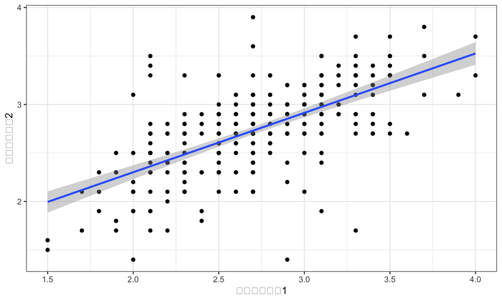

```r
graph
```

## X：ストレス，Y：バーンアウト2

- こんな感じのコードができます．

```r
# You need the following package(s):
library("ggplot2")

# The code below will generate the graph:
graph <- ggplot(ストレス, aes(x = ストレス, y = バーンアウト2)) +
  geom_point()+
  geom_smooth(se = TRUE, method = 'lm') +
  theme_bw()
```

同様に，こんなグラフが算出されます．

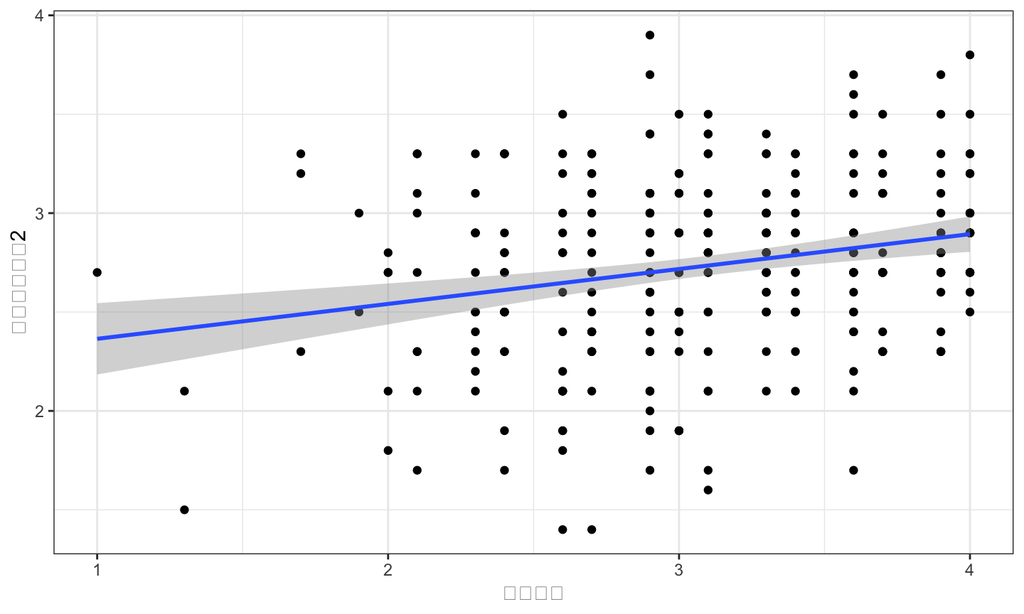

```r
graph
```

## X：サポート，Y：バーンアウト2

- こんな感じのコードができます．

```r
# You need the following package(s):
library("ggplot2")

# The code below will generate the graph:
graph <- ggplot(ストレス, aes(x = サポート, y = バーンアウト2)) +
  geom_point()+
  geom_smooth(se = TRUE, method = 'lm') +
  theme_bw()
```

同様に，こんなグラフが算出されます．

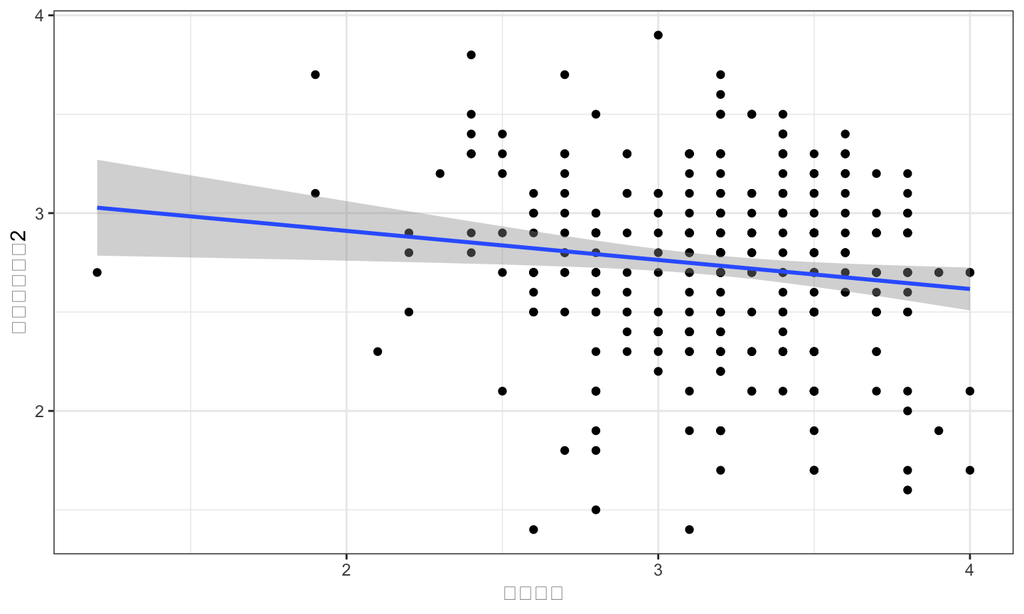

```r
graph
```

## モデル1

- モデル1の作成・分析を行う．

```r
#"model1"というオブジェクトに，分析モデルを代入する．
model1<-lm(バーンアウト2 ~ バーンアウト1, data = ストレス)
```

```r
#分析結果の要約を出力する
summary(model1)
```

```
##
## Call:
## lm(formula = バーンアウト2 ~ バーンアウト1, data = ストレス)
##
## Residuals:
##      Min       1Q   Median       3Q      Max
## -1.45239 -0.19833  0.03135  0.20417  1.17010
##
## Coefficients:
##               Estimate Std. Error t value Pr(>|t|)
## (Intercept)     1.0762     0.1184   9.087   <2e-16 ***
## バーンアウト1   0.6125     0.0431  14.211   <2e-16 ***
## ---
## Signif. codes:  0 '***' 0.001 '**' 0.01 '*' 0.05 '.' 0.1 ' ' 1
##
## Residual standard error: 0.3464 on 298 degrees of freedom
## Multiple R-squared:  0.4039, Adjusted R-squared:  0.4019
## F-statistic:   202 on 1 and 298 DF,  p-value: < 2.2e-16
```

\[ \begin{aligned} \operatorname{バーンアウト2} &= 1.08 + 0.61(\operatorname{バーンアウト1}) + \epsilon \end{aligned} \]

- 1回目でのバーンアウトが強い人ほど，2回目でのバーンアウトも強い．
  - 十分に想像できる結果だと思いますよね？
- Multiple R-squared（決定係数・分散説明率）が0.4039である．

## モデル2

- モデル2の作成・分析を行う．

```r
#"model2"というオブジェクトに，分析モデルを代入する．
model2<-lm(バーンアウト2 ~ バーンアウト1+ ストレス + サポート,
                 data = ストレス)
```

```r
#分析結果の要約を出力する
summary(model2)
```

```
##
## Call:
## lm(formula = バーンアウト2 ~ バーンアウト1 + ストレス +
##     サポート, data = ストレス)
##
## Residuals:
##      Min       1Q   Median       3Q      Max
## -1.45704 -0.18085  0.01779  0.20892  1.17174
##
## Coefficients:
##               Estimate Std. Error t value Pr(>|t|)
## (Intercept)    1.19234    0.20905   5.704 2.84e-08 ***
## バーンアウト1  0.58006    0.04466  12.989  < 2e-16 ***
## ストレス       0.07418    0.03452   2.149   0.0324 *
## サポート      -0.08091    0.04770  -1.696   0.0909 .
## ---
## Signif. codes:  0 '***' 0.001 '**' 0.01 '*' 0.05 '.' 0.1 ' ' 1
##
## Residual standard error: 0.3438 on 296 degrees of freedom
## Multiple R-squared:  0.4168, Adjusted R-squared:  0.4109
## F-statistic: 70.52 on 3 and 296 DF,  p-value: < 2.2e-16
```

\[ \operatorname{バーンアウト2} = 1.19 + 0.58(\operatorname{バーンアウト1}) \\ + 0.07(\operatorname{ストレス}) - 0.08(\operatorname{サポート}) + \epsilon \]

- ストレスが5%水準で統計的に有意にポジティブ
- サポートが統計的に有意とは言えない．
  - 10%水準であればネガティブ
- Multiple R-squared（決定係数・分散説明率）が0.4168であり，Adjusted R-squared（自由度調整済み決定係数）が0.4109である．

## モデル1とモデル2の比較

```r
anova(model1, model2)
```

```
## Analysis of Variance Table
##
## Model 1: バーンアウト2 ~ バーンアウト1
## Model 2: バーンアウト2 ~ バーンアウト1 + ストレス + サポート
##   Res.Df    RSS Df Sum of Sq      F  Pr(>F)
## 1    298 35.765
## 2    296 34.993  2   0.77178 3.2642 0.03961 *
## ---
## Signif. codes:  0 '***' 0.001 '**' 0.01 '*' 0.05 '.' 0.1 ' ' 1
```

- ’model1’と’model2’のいずれが説明力が強いか．
- 今回の結果は’model1’よりも’model2’が統計的に有意に説明力が強いことを示している．
  - ストレスとサポートを入れることで，よりバーンアウト2を説明できる．

## その他の指標

- AICとBIC

```r
extractAIC(model1)
```

```
## [1]    2.0000 -634.0462
```

```r
extractAIC(model2)
```

```
## [1]    4.0000 -636.5908
```

- モデル2の方がAICが小さい

```r
extractAIC(model1, k=log(300))
```

```
## [1]    2.0000 -626.6386
```

```r
extractAIC(model2, k=log(300))
```

```
## [1]    4.0000 -621.7757
```

## 交互作用を考える

## 交互作用を入れる場合・入れない場合

- 交互作用自身に興味がある場合
  - 交互作用が「あるとはいえない」ことを主張したい場合も
- データを眺めて交互作用が確認できる場合
- 理論や知識から交互作用の存在を予想できる場合

## 交互作用を考える

- モデル3として交互作用を入れてみよう
- モデル3

\[(バーンアウト2)_i=\beta_1 (バーンアウト1) +\beta_2 (ストレス) \\ +\beta_3 (サポート) +\beta_4 (サポート)×(ストレス) + \alpha+\epsilon_i \]

- 回帰係数\(\beta_4\)が有意になることで交互作用を認めることができる．式変形をして考えてみよう．
- モデル3’

\[(バーンアウト2)_i=\beta_1 (バーンアウト1) +\\(\beta_2 + \beta_4×サポート)× (ストレス)\\ +\beta_3 (サポート) + \alpha+\epsilon_i \]

- ストレスの偏回帰係数が(\(\beta_2\) + \(\beta_4\)×サポート)である．
- バーンアウト2とストレスの関係は，ソーシャルサポートの程度によって変化する．
- 春学期の終わりに触れた「交互作用あり」の分散分析モデルと同じことが，説明変数が数値データでも利用できる．

## 交互作用に存在する課題

- **多重共線性**：交互作用項はもともとの変数と高い相関を示しがち．そうなると．．．
  - 回帰係数の標準誤差が大きくなりがち
  - 回帰係数の符号が逆転してしまう可能性があり
  - 回帰係数が収束せず，うま推定できないこともあり
- 多重共線性への対応として**中心化**を行う必要がある．
  - 特に数値データの交互作用に着目する場合
- **中心化**：ある変数の得点から，その変数の平均値を引くこと
  - 中心化をする前と中心化をした後で，交互作用項の偏回帰係数は変わらないが多重共線性を避けられる．

## 中心化

```r
# ストレスの中心化
ストレス$ストレス中心 <- ストレス$ストレス - mean(ストレス$ストレス)

# サポートの中心化
ストレス$サポート中心 <- ストレス$サポート - mean(ストレス$サポート)

# バーンアウト1の中心化
ストレス$バーンアウト1中心 <- ストレス$バーンアウト1
- mean(ストレス$バーンアウト1)
```

```
## [1] -2.708333
```

## 交互作用の作成

```r
# 交互作用
ストレス$交互作用 <- ストレス$ストレス * ストレス$サポート


# 中心化した後の交互作用
ストレス$交互作用中心 <- ストレス$ストレス中心 * ストレス$サポート中心
```

## データの確認

```r
DT::datatable(ストレス)
```

|  | ストレス | サポート | バーンアウト1 | バーンアウト2 | ストレス中心 | サポート中心 | バーンアウト1中心 | 交互作用 | 交互作用中心 |
| --- | --- | --- | --- | --- | --- | --- | --- | --- | --- |
| 1 | 2.9 | 3.3 | 2.2 | 2.3 | -0.2 | 0.107333333333333 | 2.2 | 9.57 | -0.0214666666666666 |
| 2 | 3.1 | 3.6 | 2.7 | 3 | 0 | 0.407333333333333 | 2.7 | 11.16 | 0 |
| 3 | 2.3 | 3.5 | 3.1 | 3.3 | -0.8 | 0.307333333333333 | 3.1 | 8.05 | -0.245866666666667 |
| 4 | 3.7 | 3.2 | 3.4 | 2.7 | 0.6 | 0.00733333333333341 | 3.4 | 11.84 | 0.00440000000000005 |
| 5 | 3.7 | 3.3 | 3.7 | 3.5 | 0.6 | 0.107333333333333 | 3.7 | 12.21 | 0.0643999999999998 |
| 6 | 2.1 | 2.8 | 3.2 | 3 | -1 | -0.392666666666667 | 3.2 | 5.88 | 0.392666666666667 |
| 7 | 2.9 | 3.5 | 2.1 | 1.9 | -0.2 | 0.307333333333333 | 2.1 | 10.15 | -0.0614666666666667 |
| 8 | 2.4 | 2.2 | 2.2 | 2.5 | -0.7 | -0.992666666666667 | 2.2 | 5.28 | 0.694866666666667 |
| 9 | 2.6 | 3.5 | 1.8 | 2.1 | -0.5 | 0.307333333333333 | 1.8 | 9.1 | -0.153666666666667 |
| 10 | 4 | 3.2 | 3 | 2.9 | 0.9 | 0.00733333333333341 | 3 | 12.8 | 0.00660000000000007 |

[output cut: 290 more lines]

## 中心化前の相関行列

```r
library(dplyr)
ストレス %>%
  select(-バーンアウト1, -バーンアウト2, -ストレス中心,
         -サポート中心,-交互作用中心, -バーンアウト1中心) %>%
  cor()
```

```
##           ストレス  サポート  交互作用
## ストレス 1.0000000 0.1180760 0.8481021
## サポート 0.1180760 1.0000000 0.6091251
## 交互作用 0.8481021 0.6091251 1.0000000
```

- ストレスと交互作用の相関係数が0.848，サポートと交互作用の相関係数が0.609
  - いずれもかなり大きいため，重回帰分析を行った際に多重共線性が生じる危険性あり

## 中心化後の相関行列

```r
library(dplyr)
ストレス %>%
  select(-バーンアウト1, -バーンアウト2, -ストレス,
         -サポート,-交互作用,-バーンアウト1中心) %>%
  cor()
```

```
##              ストレス中心 サポート中心 交互作用中心
## ストレス中心   1.00000000    0.1180760  -0.09977173
## サポート中心   0.11807601    1.0000000  -0.23594740
## 交互作用中心  -0.09977173   -0.2359474   1.00000000
```

- ストレスと交互作用の相関係数が-0.099，サポートと交互作用の相関係数が-0.235
  - いずれも十分に小さくなっているために，このまま分析できそう．

## モデル3

- モデル3の作成・分析を行う．

```r
#"model3"というオブジェクトに，分析モデルを代入する．
model3<-lm(バーンアウト2 ~ バーンアウト1中心+ ストレス中心
                 + サポート中心+ ストレス中心:サポート中心,
                 data = ストレス)
```

```r
#分析結果の要約を出力する
summary(model3)
```

```
##
## Call:
## lm(formula = バーンアウト2 ~ バーンアウト1中心 +
##     ストレス中心 + サポート中心 + ストレス中心:サポート中心,
##     data = ストレス)
##
## Residuals:
##      Min       1Q   Median       3Q      Max
## -1.43353 -0.17514  0.00955  0.21465  1.16380
##
## Coefficients:
##                           Estimate Std. Error t value Pr(>|t|)
## (Intercept)                1.19182    0.12194   9.774   <2e-16 ***
## バーンアウト1中心          0.57152    0.04438  12.878   <2e-16 ***
## ストレス中心               0.06962    0.03425   2.032   0.0430 *
## サポート中心              -0.11006    0.04864  -2.263   0.0244 *
## ストレス中心:サポート中心 -0.15558    0.06121  -2.542   0.0115 *
## ---
## Signif. codes:  0 '***' 0.001 '**' 0.01 '*' 0.05 '.' 0.1 ' ' 1
##
## Residual standard error: 0.3407 on 295 degrees of freedom
## Multiple R-squared:  0.4293, Adjusted R-squared:  0.4216
## F-statistic: 55.48 on 4 and 295 DF,  p-value: < 2.2e-16
```

## モデル3と同値のモデル

- モデル3の同値のモデルの作成・分析を行う．

```r
#"model3_1"というオブジェクトに，分析モデルを代入する．
model3_1<-lm(バーンアウト2 ~ バーンアウト1中心
                   + ストレス中心 * サポート中心,
                   data = ストレス)
```

- ’ストレス中心:サポート中心’の代わりに’ストレス中心 * サポート中心’になっている．
  - ’ストレス中心+サポート中心+ストレス中心:サポート中心’と’ストレス中心 * サポート中心’が同値

```r
#分析結果の要約を出力する
summary(model3_1)
```

```
##
## Call:
## lm(formula = バーンアウト2 ~ バーンアウト1中心 +
##     ストレス中心 * サポート中心, data = ストレス)
##
## Residuals:
##      Min       1Q   Median       3Q      Max
## -1.43353 -0.17514  0.00955  0.21465  1.16380
##
## Coefficients:
##                           Estimate Std. Error t value Pr(>|t|)
## (Intercept)                1.19182    0.12194   9.774   <2e-16 ***
## バーンアウト1中心          0.57152    0.04438  12.878   <2e-16 ***
## ストレス中心               0.06962    0.03425   2.032   0.0430 *
## サポート中心              -0.11006    0.04864  -2.263   0.0244 *
## ストレス中心:サポート中心 -0.15558    0.06121  -2.542   0.0115 *
## ---
## Signif. codes:  0 '***' 0.001 '**' 0.01 '*' 0.05 '.' 0.1 ' ' 1
##
## Residual standard error: 0.3407 on 295 degrees of freedom
## Multiple R-squared:  0.4293, Adjusted R-squared:  0.4216
## F-statistic: 55.48 on 4 and 295 DF,  p-value: < 2.2e-16
```

## モデル3の解釈

- ストレスが高くて，サポートが多い人のバーンアウト2は，5%水準で統計的に有意に低い．
- 交互作用のあるモデルは解釈が難しいので，グラフなどとあわせて示してあげると良い．
- 次回改めて紹介する．

## モデル1とモデル2，モデル3の比較

```r
anova(model1, model2, model3)
```

```
## Analysis of Variance Table
##
## Model 1: バーンアウト2 ~ バーンアウト1
## Model 2: バーンアウト2 ~ バーンアウト1 + ストレス + サポート
## Model 3: バーンアウト2 ~ バーンアウト1中心 + ストレス中心 +
##     サポート中心 + ストレス中心:サポート中心
##   Res.Df    RSS Df Sum of Sq      F  Pr(>F)
## 1    298 35.765
## 2    296 34.993  2   0.77178 3.3244 0.03735 *
## 3    295 34.243  1   0.74997 6.4609 0.01154 *
## ---
## Signif. codes:  0 '***' 0.001 '**' 0.01 '*' 0.05 '.' 0.1 ' ' 1
```

- ’model1’と’model2’と’model3’のいずれが説明力が強いか．
- 今回の結果は’model1’よりも’model2’が，’model12’よりも’model3’が統計的に有意に説明力が強いことを示している．
  - 交互作用項を入れることで，よりバーンアウト2を説明できる．

## 演習問題

## 演習問題

- 教科書p113の章末演習の問1-問3までをやってみましょう
  - データの読み込み方は今回と同じように以下の手続きが必要です．
- Macの場合(一部のwindowsを含む)では素直には読み込めないが，Import Dataset -> From Text(readr)… -> Import Options -> Locale ->encodingをUTF-8からSHIFT-JISに変更して“Configure”をクリック